# Actividad4

Berenice Juarez Gonzalez

2025-05-21

INTRODUCCIÓN

La deserción estudiantil representa un desafío crítico para las instituciones educativas. Comprender qué factores están asociados al abandono puede ayudar a implementar políticas de apoyo académico más efectivas.

Este análisis tiene como objetivo explorar un conjunto de datos reales de estudiantes, identificando posibles patrones y variables que influyen en la deserción, con especial énfasis en el rendimiento académico previo.

EXPLORACION Y LIMPIEZA DE DATOS

Carga de Datos

```r
# Cargar archivo CSV con separador ";"
data <- read.csv("data.csv", sep = ";")

# Vista general de los primeros registros
head(data)
```

|  | Marital.status | Application.mode | Application.order | Course | Daytime.evening.attendance. | Previous.qualification | Previous.qualification..grade. | Nacionality | Mother.s.qualification | Father.s.qualification | Mother.s.occupation | Father.s.occupation | Admission.grade | Displaced | Educational.special.needs | Debtor | Tuition.fees.up.to.date | Gender | Scholarship.holder | Age.at.enrollment | International | Curricular.units.1st.sem..credited. | Curricular.units.1st.sem..enrolled. | Curricular.units.1st.sem..evaluations. | Curricular.units.1st.sem..approved. | Curricular.units.1st.sem..grade. | Curricular.units.1st.sem..without.evaluations. | Curricular.units.2nd.sem..credited. | Curricular.units.2nd.sem..enrolled. | … |
| --- | --- | --- | --- | --- | --- | --- | --- | --- | --- | --- | --- | --- | --- | --- | --- | --- | --- | --- | --- | --- | --- | --- | --- | --- | --- | --- | --- | --- | --- | --- |
| 1 | 1 | 17 | 5 | 171 | 1 | 1 | 122.0 | 1 | 19 | 12 | 5 | 9 | 127.3 | 1 | 0 | 0 | 1 | 1 | 0 | 20 | 0 | 0 | 0 | 0 | 0 | 0.00000 | 0 | 0 | 0 | … |
| 2 | 1 | 15 | 1 | 9254 | 1 | 1 | 160.0 | 1 | 1 | 3 | 3 | 3 | 142.5 | 1 | 0 | 0 | 0 | 1 | 0 | 19 | 0 | 0 | 6 | 6 | 6 | 14.00000 | 0 | 0 | 6 | … |
| 3 | 1 | 1 | 5 | 9070 | 1 | 1 | 122.0 | 1 | 37 | 37 | 9 | 9 | 124.8 | 1 | 0 | 0 | 0 | 1 | 0 | 19 | 0 | 0 | 6 | 0 | 0 | 0.00000 | 0 | 0 | 6 | … |
| 4 | 1 | 17 | 2 | 9773 | 1 | 1 | 122.0 | 1 | 38 | 37 | 5 | 3 | 119.6 | 1 | 0 | 0 | 1 | 0 | 0 | 20 | 0 | 0 | 6 | 8 | 6 | 13.42857 | 0 | 0 | 6 | … |
| 5 | 2 | 39 | 1 | 8014 | 0 | 1 | 100.0 | 1 | 37 | 38 | 9 | 9 | 141.5 | 0 | 0 | 0 | 1 | 0 | 0 | 45 | 0 | 0 | 6 | 9 | 5 | 12.33333 | 0 | 0 | 6 | … |
| 6 | 2 | 39 | 1 | 9991 | 0 | 19 | 133.1 | 1 | 37 | 37 | 9 | 7 | 114.8 | 0 | 0 | 1 | 1 | 1 | 0 | 50 | 0 | 0 | 5 | 10 | 5 | 11.85714 | 0 | 0 | 5 | … |

Estructura y Resumen

```r
# Estructura de los datos
str(data)
```

```
## 'data.frame':    4424 obs. of  37 variables:
##  $ Marital.status                                : int  1 1 1 1 2 2 1 1 1 1 ...
##  $ Application.mode                              : int  17 15 1 17 39 39 1 18 1 1 ...
##  $ Application.order                             : int  5 1 5 2 1 1 1 4 3 1 ...
##  $ Course                                        : int  171 9254 9070 9773 8014 9991 9500 9254 9238 9238 ...
##  $ Daytime.evening.attendance.                   : int  1 1 1 1 0 0 1 1 1 1 ...
##  $ Previous.qualification                        : int  1 1 1 1 1 19 1 1 1 1 ...
##  $ Previous.qualification..grade.                : num  122 160 122 122 100 ...
##  $ Nacionality                                   : int  1 1 1 1 1 1 1 1 62 1 ...
##  $ Mother.s.qualification                        : int  19 1 37 38 37 37 19 37 1 1 ...
##  $ Father.s.qualification                        : int  12 3 37 37 38 37 38 37 1 19 ...
##  $ Mother.s.occupation                           : int  5 3 9 5 9 9 7 9 9 4 ...
##  $ Father.s.occupation                           : int  9 3 9 3 9 7 10 9 9 7 ...
##  $ Admission.grade                               : num  127 142 125 120 142 ...
##  $ Displaced                                     : int  1 1 1 1 0 0 1 1 0 1 ...
```

[output cut: 23 more lines]

```r
# Estadísticas generales
summary(data)
```

```
##  Marital.status  Application.mode Application.order     Course
##  Min.   :1.000   Min.   : 1.00    Min.   :0.000     Min.   :  33
##  1st Qu.:1.000   1st Qu.: 1.00    1st Qu.:1.000     1st Qu.:9085
##  Median :1.000   Median :17.00    Median :1.000     Median :9238
##  Mean   :1.179   Mean   :18.67    Mean   :1.728     Mean   :8857
##  3rd Qu.:1.000   3rd Qu.:39.00    3rd Qu.:2.000     3rd Qu.:9556
##  Max.   :6.000   Max.   :57.00    Max.   :9.000     Max.   :9991
##  Daytime.evening.attendance. Previous.qualification
##  Min.   :0.0000              Min.   : 1.000
##  1st Qu.:1.0000              1st Qu.: 1.000
##  Median :1.0000              Median : 1.000
##  Mean   :0.8908              Mean   : 4.578
##  3rd Qu.:1.0000              3rd Qu.: 1.000
##  Max.   :1.0000              Max.   :43.000
##  Previous.qualification..grade.  Nacionality      Mother.s.qualification
##  Min.   : 95.0                  Min.   :  1.000   Min.   : 1.00
##  1st Qu.:125.0                  1st Qu.:  1.000   1st Qu.: 2.00
##  Median :133.1                  Median :  1.000   Median :19.00
##  Mean   :132.6                  Mean   :  1.873   Mean   :19.56
##  3rd Qu.:140.0                  3rd Qu.:  1.000   3rd Qu.:37.00
##  Max.   :190.0                  Max.   :109.000   Max.   :44.00
##  Father.s.qualification Mother.s.occupation Father.s.occupation Admission.grade
##  Min.   : 1.00          Min.   :  0.00      Min.   :  0.00      Min.   : 95.0
##  1st Qu.: 3.00          1st Qu.:  4.00      1st Qu.:  4.00      1st Qu.:117.9
##  Median :19.00          Median :  5.00      Median :  7.00      Median :126.1
##  Mean   :22.28          Mean   : 10.96      Mean   : 11.03      Mean   :127.0
##  3rd Qu.:37.00          3rd Qu.:  9.00      3rd Qu.:  9.00      3rd Qu.:134.8
##  Max.   :44.00          Max.   :194.00      Max.   :195.00      Max.   :190.0
##    Displaced      Educational.special.needs     Debtor
##  Min.   :0.0000   Min.   :0.00000           Min.   :0.0000
##  1st Qu.:0.0000   1st Qu.:0.00000           1st Qu.:0.0000
##  Median :1.0000   Median :0.00000           Median :0.0000
##  Mean   :0.5484   Mean   :0.01153           Mean   :0.1137
##  3rd Qu.:1.0000   3rd Qu.:0.00000           3rd Qu.:0.0000
##  Max.   :1.0000   Max.   :1.00000           Max.   :1.0000
##  Tuition.fees.up.to.date     Gender       Scholarship.holder Age.at.enrollment
##  Min.   :0.0000          Min.   :0.0000   Min.   :0.0000     Min.   :17.00
##  1st Qu.:1.0000          1st Qu.:0.0000   1st Qu.:0.0000     1st Qu.:19.00
##  Median :1.0000          Median :0.0000   Median :0.0000     Median :20.00
##  Mean   :0.8807          Mean   :0.3517   Mean   :0.2484     Mean   :23.27
```

[output cut: 50 more lines]

```
##  Max.   :18.57
##  Curricular.units.2nd.sem..without.evaluations. Unemployment.rate
##  Min.   : 0.0000                                Min.   : 7.60
##  1st Qu.: 0.0000                                1st Qu.: 9.40
##  Median : 0.0000                                Median :11.10
##  Mean   : 0.1503                                Mean   :11.57
##  3rd Qu.: 0.0000                                3rd Qu.:13.90
##  Max.   :12.0000                                Max.   :16.20
##  Inflation.rate        GDP               Target
##  Min.   :-0.800   Min.   :-4.060000   Length:4424
##  1st Qu.: 0.300   1st Qu.:-1.700000   Class :character
##  Median : 1.400   Median : 0.320000   Mode  :character
##  Mean   : 1.228   Mean   : 0.001969
##  3rd Qu.: 2.600   3rd Qu.: 1.790000
##  Max.   : 3.700   Max.   : 3.510000
```

Revisión de valores NA

```r
# Recuento de valores NA por columna
total_na <- colSums(is.na(data))
kable(as.data.frame(total_na), caption = "Valores faltantes por columna")
```

Valores faltantes por columna

|  | total_na |
| --- | --- |
| Marital.status | 0 |
| Application.mode | 0 |
| Application.order | 0 |
| Course | 0 |
| Daytime.evening.attendance. | 0 |
| Previous.qualification | 0 |
| Previous.qualification..grade. | 0 |
| Nacionality | 0 |
| Mother.s.qualification | 0 |
| Father.s.qualification | 0 |
| Mother.s.occupation | 0 |
| Father.s.occupation | 0 |
| Admission.grade | 0 |
| Displaced | 0 |
| Educational.special.needs | 0 |
| Debtor | 0 |
| Tuition.fees.up.to.date | 0 |
| Gender | 0 |
| Scholarship.holder | 0 |
| Age.at.enrollment | 0 |
| International | 0 |
| Curricular.units.1st.sem..credited. | 0 |
| Curricular.units.1st.sem..enrolled. | 0 |
| Curricular.units.1st.sem..evaluations. | 0 |
| Curricular.units.1st.sem..approved. | 0 |
| Curricular.units.1st.sem..grade. | 0 |
| Curricular.units.1st.sem..without.evaluations. | 0 |
| Curricular.units.2nd.sem..credited. | 0 |
| Curricular.units.2nd.sem..enrolled. | 0 |
| Curricular.units.2nd.sem..evaluations. | 0 |
| Curricular.units.2nd.sem..approved. | 0 |
| Curricular.units.2nd.sem..grade. | 0 |
| Curricular.units.2nd.sem..without.evaluations. | 0 |
| Unemployment.rate | 0 |
| Inflation.rate | 0 |
| GDP | 0 |
| Target | 0 |

Limpieza de Datos

```r
# Eliminamos columnas irrelevantes (por ejemplo, Nacionality)
data <- data %>% select(-c(Nacionality))

# Creamos una variable con el promedio de calificaciones anteriores
data <- data %>% mutate(Promedio_Nota_Previa = rowMeans(select(., starts_with("Curricular.units")), na.rm = TRUE))
```

VISUALIZACIÓN Y ANÁLISIS

Estadísticas de notas previas

```r
# Media y mediana de calificación previa
mean(data$Previous.qualification..grade., na.rm = TRUE)
```

```
## [1] 132.6133
```

```r
median(data$Previous.qualification..grade., na.rm = TRUE)
```

```
## [1] 133.1
```

Estudiantes que Abandonaron

```r
# Filtrado de estudiantes que abandonaron
abandonaron <- data %>% filter(Target == "Dropout")

# Mostramos algunos registros
kable(head(abandonaron), caption = "Ejemplos de estudiantes que abandonaron")
```

Ejemplos de estudiantes que abandonaron

| Marital.status | Application.mode | Application.order | Course | Daytime.evening.attendance. | Previous.qualification | Previous.qualification..grade. | Mother.s.qualification | Father.s.qualification | Mother.s.occupation | Father.s.occupation | Admission.grade | Displaced | Educational.special.needs | Debtor | Tuition.fees.up.to.date | Gender | Scholarship.holder | Age.at.enrollment | International | Curricular.units.1st.sem..credited. | Curricular.units.1st.sem..enrolled. | Curricular.units.1st.sem..evaluations. | Curricular.units.1st.sem..approved. | Curricular.units.1st.sem..grade. | Curricular.units.1st.sem..without.evaluations. | Curricular.units.2nd.sem..credited. | Curricular.units.2nd.sem..enrolled. | Curricular.units.2nd.sem..evaluations. | Curricular.units.2nd.sem..approved. | … |
| --- | --- | --- | --- | --- | --- | --- | --- | --- | --- | --- | --- | --- | --- | --- | --- | --- | --- | --- | --- | --- | --- | --- | --- | --- | --- | --- | --- | --- | --- | --- |
| 1 | 17 | 5 | 171 | 1 | 1 | 122 | 19 | 12 | 5 | 9 | 127.3 | 1 | 0 | 0 | 1 | 1 | 0 | 20 | 0 | 0 | 0 | 0 | 0 | 0.0 | 0 | 0 | 0 | 0 | 0 | … |
| 1 | 1 | 5 | 9070 | 1 | 1 | 122 | 37 | 37 | 9 | 9 | 124.8 | 1 | 0 | 0 | 0 | 1 | 0 | 19 | 0 | 0 | 6 | 0 | 0 | 0.0 | 0 | 0 | 6 | 0 | 0 | … |
| 1 | 18 | 4 | 9254 | 1 | 1 | 119 | 37 | 37 | 9 | 9 | 113.1 | 1 | 0 | 0 | 0 | 1 | 0 | 22 | 0 | 0 | 5 | 5 | 0 | 0.0 | 0 | 0 | 5 | 5 | 0 | … |
| 1 | 1 | 1 | 9238 | 1 | 1 | 138 | 1 | 19 | 4 | 7 | 123.0 | 1 | 0 | 1 | 0 | 0 | 0 | 18 | 0 | 0 | 6 | 9 | 5 | 11.4 | 0 | 0 | 6 | 14 | 2 | … |
| 1 | 1 | 2 | 9853 | 1 | 1 | 133 | 19 | 37 | 4 | 9 | 130.2 | 1 | 0 | 0 | 1 | 0 | 0 | 19 | 0 | 0 | 6 | 6 | 0 | 0.0 | 0 | 0 | 6 | 0 | 0 | … |
| 1 | 1 | 1 | 9773 | 1 | 1 | 127 | 19 | 37 | 9 | 3 | 120.7 | 1 | 0 | 0 | 1 | 0 | 0 | 20 | 0 | 0 | 6 | 6 | 5 | 13.2 | 0 | 0 | 6 | 7 | 0 | … |

Boxplot: Calificaciones anteriores por estado final

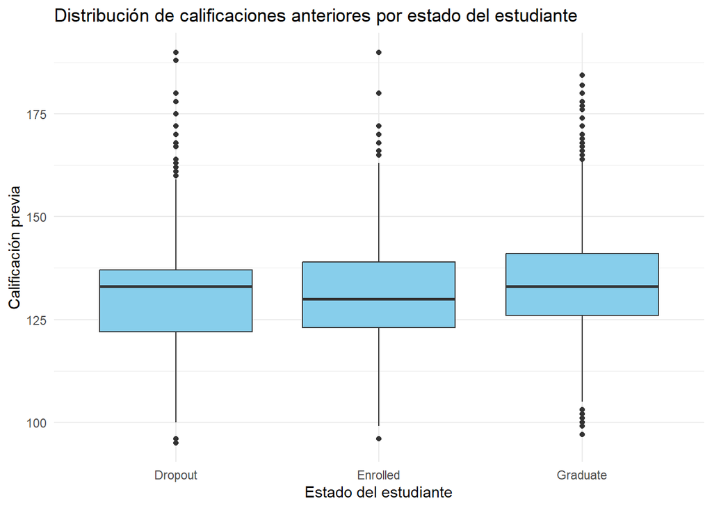

```r
ggplot(data, aes(x = Target, y = Previous.qualification..grade.)) +
  geom_boxplot(fill = "skyblue") +
  labs(title = "Distribución de calificaciones anteriores por estado del estudiante",
       x = "Estado del estudiante", y = "Calificación previa") +
  theme_minimal()
```

Histograma: Unidades curriculares aprobadas en el primer semestre

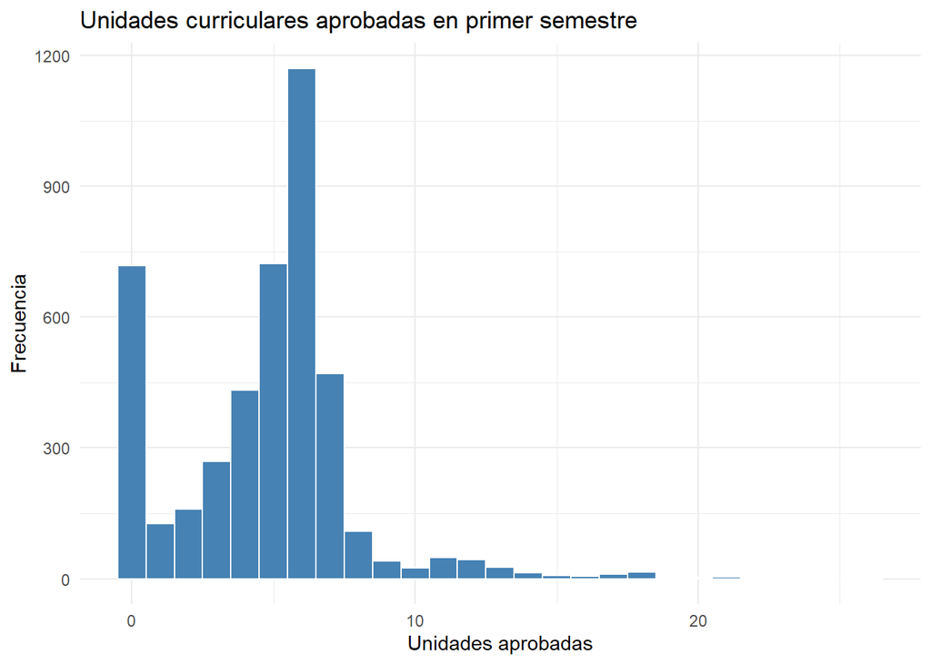

```r
ggplot(data, aes(x = Curricular.units.1st.sem..approved.)) +
  geom_histogram(binwidth = 1, fill = "steelblue", color = "white") +
  labs(title = "Unidades curriculares aprobadas en primer semestre",
       x = "Unidades aprobadas", y = "Frecuencia") +
  theme_minimal()
```

Interpretación: Muchos estudiantes aprueban entre 0 y 5 materias en el primer semestre. Este bajo rendimiento puede estar relacionado con la deserción temprana.

Las visualizaciones ayudan a identificar patrones importantes que podrían servir para establecer intervenciones académicas tempranas.